# simon-5502-12-demo

## File details

This program was written by Steve Simon on 2025-04-12 and is placed in the public domain. You can use this program any way you please.

```r
library(broom)
library(foreign)
library(lme4)
library(tidyverse)

R.version.string
```

```
[1] "R version 4.5.0 (2025-04-11 ucrt)"
```

```r
Sys.Date()
```

```
[1] "2026-04-14"
```

#### Comments on the code

The [foreign library](https://CRAN.R-project.org/package=foreign) allows you to import binary data files from various proprietary packages, such as SAS, SPSS, and Stata.

——————————Begin part 1————————————–

## Read oa

```r
oa <- read_table(
  file="../data/arthritis-treatments.txt",
  col_names=TRUE,
  col_types="nnnnnnn")

glimpse(oa)
```

```
Rows: 10
Columns: 7
$ Subject <dbl> 1, 2, 3, 4, 5, 6, 7, 8, 9, 10
$ NoROM   <dbl> 35, 110, 101, 99, 126, 118, 117, 73, 95, 110
$ NoVAS   <dbl> 5.3, 2.0, 1.1, 6.3, 4.0, 0.9, 2.0, 6.1, 5.2, 2.2
$ TENSROM <dbl> 50, 90, 110, 103, 137, 89, 70, 68, 38, 87
$ TENSVAS <dbl> 3.8, 7.3, 3.6, 4.0, 1.9, 5.6, 6.6, 4.1, 7.7, 4.8
$ SWDROM  <dbl> 64, 120, 116, 135, 150, 100, 74, 93, 100, 73
$ SWDVAS  <dbl> 7.0, 1.6, 2.4, 0.8, 1.0, 2.0, 8.0, 4.5, 2.3, 4.0
```

## Create subset for ROM

```r
oa |>
  select(
    Subject,
    NoROM,
    TENSROM,
    SWDROM) |>
  rename(
    no=NoROM,
    tens=TENSROM,
    swd=SWDROM) -> oa_1
```

## Restructure into long format

```r
oa_1 |>
  pivot_longer(
    cols=no:swd,
    names_to="treatment",
    values_to="rom") -> oa_2

glimpse(oa_2)
```

```
Rows: 30
Columns: 3
$ Subject   <dbl> 1, 1, 1, 2, 2, 2, 3, 3, 3, 4, 4, 4, 5, 5, 5, 6, 6, 6, 7, 7, …
$ treatment <chr> "no", "tens", "swd", "no", "tens", "swd", "no", "tens", "swd…
$ rom       <dbl> 35, 50, 64, 110, 90, 120, 101, 110, 116, 99, 103, 135, 126, …
```

#### Comments on the code

The [pivot_longer](https://tidyr.tidyverse.org/reference/pivot_longer.html) function is in the [tidyr](https://tidyr.tidyverse.org/) package, which is part of the tidyverse.

## Descriptive statistics

```r
oa_2 |>
  group_by(treatment) |>
  summarize(
    rom_mean=mean(rom),
    rom_sd=sd(rom)) -> oa_means

oa_means
```

```
# A tibble: 3 × 3
  treatment rom_mean rom_sd
  <chr>        <dbl>  <dbl>
1 no            98.4   26.8
2 swd          102.    28.0
3 tens          84.2   29.1
```

#### Interpretation of the output

There is a slight improvement in range of motion using swd versus no treatment. Using tens actually decreases the range of motion.

## Plot by subject

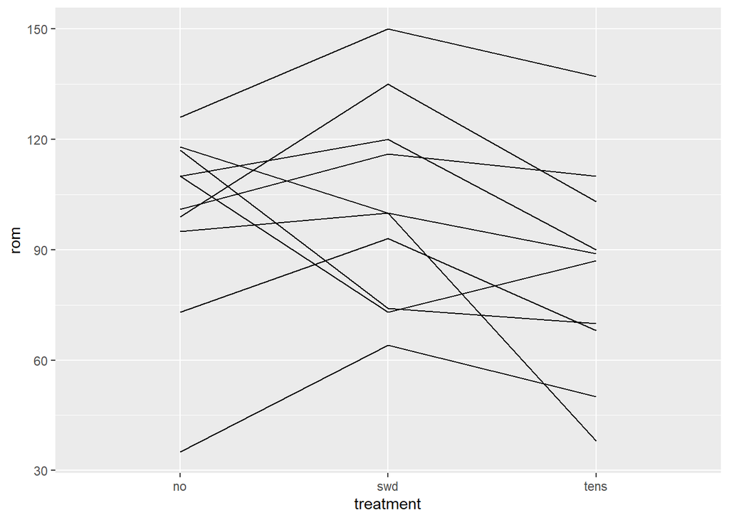

```r
oa_2 |>
  ggplot() +
  aes(
    x = treatment,
    y = rom,
    group = Subject) +
  geom_line() -> oa_plot

oa_plot
```

#### Interpretation of the output

There is a tendency for some subjects to see the best range of motion under swd, but there are a few exceptions.

## Mixed model for oa

```r
m1 <- lmer(
  rom ~ treatment + (1 | Subject),
  data=oa_2)

summary(m1)
```

```
Linear mixed model fit by REML ['lmerMod']
Formula: rom ~ treatment + (1 | Subject)
   Data: oa_2

REML criterion at convergence: 253.5

Scaled residuals:
    Min      1Q  Median      3Q     Max
-1.8326 -0.4790  0.1129  0.6702  1.4533

Random effects:
 Groups   Name        Variance Std.Dev.
 Subject  (Intercept) 481.7    21.95
 Residual             301.8    17.37
Number of obs: 30, groups:  Subject, 10

Fixed effects:
              Estimate Std. Error t value
(Intercept)     98.400      8.851  11.117
treatmentswd     4.100      7.769   0.528
treatmenttens  -14.200      7.769  -1.828

Correlation of Fixed Effects:
            (Intr) trtmnts
treatmntswd -0.439
treatmnttns -0.439  0.500
```

#### Comments on the code

The [lmer](https://cran.r-project.org/web/packages/multilevelTools/vignettes/lmer-vignette.html) function is part of the lme4 package. The package is quite detailed, but you only need to use some basic parts of it. The lmer function uses a similar approach as the lm function. You specify a model with a formula that includes a tilde(~). The dependent variable goes on the left side of the tilde and the independent variables plus the cluster variable goes on the right side. The cluster variable needs to be defined as (1 | *cluster-variable*). This might seem a bit strange, but the syntax is required for more complex models than what you will be using, at least at the start.

The output from lmer is quite verbose and there is no easy way to select just what you want. You do want to use the summary function, which provides a list of fixed and random effects.

I have not found a simple function that will compute the intraclass correlation. It is easy enough for you to calculate by hand.

#### Interpretation of the output

The estimated range of motion in the reference category (treament=no) is 98 degrees. The range of motion for treatment=swd is 4 degree larger than treatment=no, which represents a very small is only slightly better result. The t-value is close to zero, so you would accept the null hypothesis and conclude that there is no statistically significant difference between the groups.

There is substantial variation between clusters (subjects are the cluster). The intraclass correlation is 481.7 / (481.7 + 301.8) = 0.61. This indicates a large degree of correlation for two measurements on the same subject.

——————————Begin part 2————————————–

## Read physical-activity

```r
pa <- read.spss(
  file="../data/physical-activity.sav",
  to.data.frame=TRUE)

glimpse(pa)
```

```
Rows: 1,129
Columns: 41
$ School                     <dbl> 1, 1, 1, 1, 1, 1, 1, 1, 1, 1, 1, 2, 2, 2, 2…
$ Group_allocation           <fct> Control, Control, Control, Control, Control…
$ Per_protocol_filter        <fct> ekskludert, ekskludert, ekskludert, eksklud…
$ Sex                        <fct> BOY, BOY, BOY, BOY, BOY, BOY, GIRL, GIRL, G…
$ Age_PRE                    <dbl> 10.132786, 10.099932, 10.458590, 10.302533,…
$ Weight_PRE                 <dbl> 61.9, 46.8, 35.0, 38.3, 63.0, NA, 42.0, 55.…
$ Height_PRE                 <dbl> 147.3, 156.8, 142.7, 136.9, 148.6, NA, 139.…
$ BMI_PRE                    <dbl> 28.52891, 19.03504, 17.18779, 20.43581, 28.…
$ WC_PRE                     <dbl> 86.3, 67.0, 58.0, 64.8, 58.3, NA, 74.5, 75.…
$ SBP_PRE                    <dbl> 113.00000, 95.33333, 92.00000, 114.66667, 1…
$ DBP_PRE                    <dbl> 56.50000, 46.00000, 61.00000, 64.33333, 61.…
$ LDL_PRE                    <dbl> 3.120000, 3.369091, 4.696364, 3.608182, 2.6…
$ HDL_PRE                    <dbl> 1.43, 1.94, 1.35, 1.49, 1.28, NA, 2.01, 1.5…
```

[output cut: 28 more lines]

## Descriptive statistics, 1

```r
pa |>
  summarize(
    mean_pre=mean(WC_PRE, na.rm=TRUE),
    mean_post=mean(WC_POST, na.rm=TRUE)) -> pa_means

pa_means
```

```
  mean_pre mean_post
1 62.00128  63.18463
```

#### Interpretation of the output

There is a small increase in waist circumference after the study is over. This may be due to natural growth over time.

## Descriptive statistics, 2

```r
pa |>
  count(School, Group_allocation) -> pa_counts

pa_counts
```

```
   School Group_allocation  n
1       1          Control 11
2       2          Control 10
3       3     Intervention 10
4       4     Intervention 28
5       6     Intervention 19
6       8          Control  9
7       9     Intervention 27
8      10          Control 11
9      12          Control 32
10     13          Control 20
11     14     Intervention 56
12     15          Control  8
13     16          Control 70
14     17          Control 28
```

[output cut: 43 more lines]

#### Interpretation of the output

There is a lot of variation in the number of subjects per school, but every school has at least 7.

## Compute change score

```r
pa |>
  mutate(change_score=WC_POST - WC_PRE) -> pa_1
```

## Draw boxplot by group

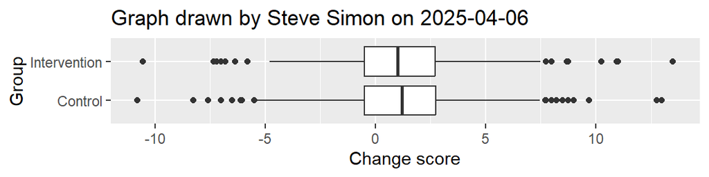

```r
pa_1 |>
  filter(!is.na(change_score)) |>
  ggplot() +
  aes(
    x=Group_allocation,
    y=change_score) +
  geom_boxplot() +
  coord_flip() +
  ggtitle("Graph drawn by Steve Simon on 2025-04-06") +
  xlab("Group") +
  ylab("Change score") -> pa_box

pa_box
```

### Interpretation of the output

The amount of increase in waist circumference is about the same in the treatment and control groups.

## Fit mixed model

```r
m2 <- lmer(
  change_score ~ Group_allocation + (1 | School),
  data=pa_1)

summary(m2)
```

```
Linear mixed model fit by REML ['lmerMod']
Formula: change_score ~ Group_allocation + (1 | School)
   Data: pa_1

REML criterion at convergence: 5013.3

Scaled residuals:
    Min      1Q  Median      3Q     Max
-4.6825 -0.5667  0.0021  0.5684  4.5686

Random effects:
 Groups   Name        Variance Std.Dev.
 School   (Intercept) 1.590    1.261
 Residual             6.578    2.565
Number of obs: 1043, groups:  School, 57

Fixed effects:
                             Estimate Std. Error t value
(Intercept)                   1.34079    0.27058   4.955
Group_allocationIntervention -0.01049    0.38135  -0.028

Correlation of Fixed Effects:
            (Intr)
Grp_llctnIn -0.710
```

#### Interpretation of the output

The estimated change in waist circumference in the reference category (Group_allocation=Control) is 1.34 centimeters. The estimated change in the treatment group versus the control group is -0.01 which is so very very slightly smaller that you might as well call it no difference at all. The t-statistic is close to zero indicating that this difference is not statistically significant.

There is a moderate amount of variation between clusters (schools are the cluster). The intraclass correlation is 1.590 / (1.590 + 6.578) = 0.19. This indicates a weak degree of correlation for two measurements within the same school.

——————————Begin part 3————————————–

## Read hiv-intervention

```r
hiv <- read_tsv(
  file="../data/hiv-intervention.txt",
  col_types="nnnnn",
  col_names=TRUE)

glimpse(hiv)
```

```
Rows: 20
Columns: 5
$ BST  <dbl> 1, 1, 1, 1, 1, 1, 1, 1, 1, 1, 0, 0, 0, 0, 0, 0, 0, 0, 0, 0
$ Pre  <dbl> 7, 25, 50, 16, 33, 10, 13, 22, 4, 17, 0, 69, 5, 4, 35, 7, 51, 25,…
$ Post <dbl> 22, 10, 36, 38, 25, 7, 33, 20, 0, 16, 0, 56, 0, 24, 8, 0, 53, 0, …
$ FU6  <dbl> 13, 17, 49, 34, 24, 23, 27, 21, 12, 20, 0, 14, 0, 0, 0, 9, 8, 0, …
$ FU12 <dbl> 14, 24, 23, 24, 25, 26, 24, 11, 0, 10, 0, 36, 5, 0, 0, 37, 26, 15…
```

## Add subject id

```r
n <- nrow(hiv)
hiv |>
  mutate(id=1:n) -> hiv_1

glimpse(hiv_1)
```

```
Rows: 20
Columns: 6
$ BST  <dbl> 1, 1, 1, 1, 1, 1, 1, 1, 1, 1, 0, 0, 0, 0, 0, 0, 0, 0, 0, 0
$ Pre  <dbl> 7, 25, 50, 16, 33, 10, 13, 22, 4, 17, 0, 69, 5, 4, 35, 7, 51, 25,…
$ Post <dbl> 22, 10, 36, 38, 25, 7, 33, 20, 0, 16, 0, 56, 0, 24, 8, 0, 53, 0, …
$ FU6  <dbl> 13, 17, 49, 34, 24, 23, 27, 21, 12, 20, 0, 14, 0, 0, 0, 9, 8, 0, …
$ FU12 <dbl> 14, 24, 23, 24, 25, 26, 24, 11, 0, 10, 0, 36, 5, 0, 0, 37, 26, 15…
$ id   <int> 1, 2, 3, 4, 5, 6, 7, 8, 9, 10, 11, 12, 13, 14, 15, 16, 17, 18, 19…
```

## Switch to long format

```r
hiv_1 |>
  pivot_longer(
    cols=Pre:FU12,
    names_to="t",
    values_to="protected_sex") |>
  mutate(t=case_when(
    t=="Pre"  ~ -6,
    t=="Post" ~  0,
    t=="FU6"  ~  6,
    t=="FU12" ~ 12)) -> hiv_2

glimpse(hiv_2)
```

```
Rows: 80
Columns: 4
$ BST           <dbl> 1, 1, 1, 1, 1, 1, 1, 1, 1, 1, 1, 1, 1, 1, 1, 1, 1, 1, 1,…
$ id            <int> 1, 1, 1, 1, 2, 2, 2, 2, 3, 3, 3, 3, 4, 4, 4, 4, 5, 5, 5,…
$ t             <dbl> -6, 0, 6, 12, -6, 0, 6, 12, -6, 0, 6, 12, -6, 0, 6, 12, …
$ protected_sex <dbl> 7, 22, 13, 14, 25, 10, 17, 24, 50, 36, 49, 23, 16, 38, 3…
```

## Plot individual subjects for treatment group

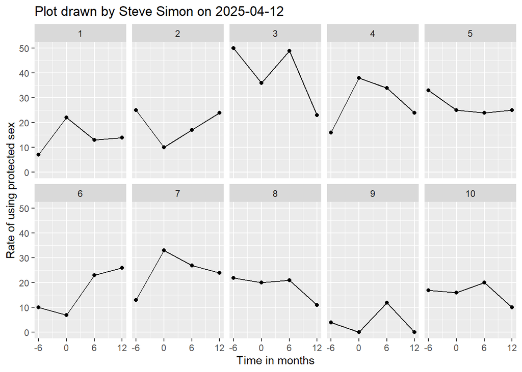

```r
hiv_2 |>
  filter(BST == 1) |>
  ggplot() +
  aes(x=t, y=protected_sex) +
  geom_point() +
  geom_line() +
  ggtitle("Plot drawn by Steve Simon on 2025-04-12") +
  xlab("Time in months") +
  ylab("Rate of using protected sex") +
  scale_x_continuous(breaks=c(-6, 0, 6, 12)) +
  facet_wrap(~ id, ncol=5) -> plot_1

plot_1
```

#### Comment on the code

The [facet_wrap](https://ggplot2.tidyverse.org/reference/facet_wrap.html) function is part of the [ggplot2](https://ggplot2.tidyverse.org/) library. It creates a series of small plots based on a subsetting variable. By default, the plots use the same scale on the X and Y axis.

#### Interpretation of the output

This graph and the one that follows show a rather chaotic state with no obvious trend or pattern across multiple patients. This leads a decision later on in this program to analyze a small subset of the data with the hope that something might emerge in that simplified setting.

## Plot individual subjects for control group

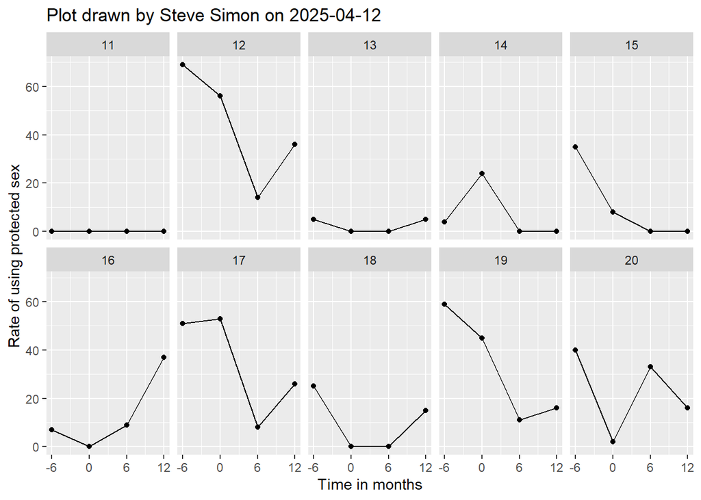

```r
hiv_2 |>
  filter(BST == 0) |>
  ggplot() +
  aes(x=t, y=protected_sex) +
  geom_point() +
  geom_line() +
  scale_x_continuous(breaks=c(-6, 0, 6, 12)) +
  ggtitle("Plot drawn by Steve Simon on 2025-04-12") +
  xlab("Time in months") +
  ylab("Rate of using protected sex") +
  facet_wrap(~ id, ncol=5) -> plot_2

plot_2
```

## Drop the pre and controls

```r
hiv_2 |>
  filter(t != -6) |>
  filter(BST != 0) -> hiv_3
```

## Fit a random intercepts model

```r
m3 <- lmer(
  protected_sex ~ t + (1 | id),
  data=hiv_3)

summary(m3)
```

```
Linear mixed model fit by REML ['lmerMod']
Formula: protected_sex ~ t + (1 | id)
   Data: hiv_3

REML criterion at convergence: 215.1

Scaled residuals:
    Min      1Q  Median      3Q     Max
-1.8385 -0.6028  0.0364  0.5183  2.1998

Random effects:
 Groups   Name        Variance Std.Dev.
 id       (Intercept) 69.57    8.341
 Residual             53.34    7.304
Number of obs: 30, groups:  id, 10

Fixed effects:
            Estimate Std. Error t value
(Intercept)  22.2333     3.3768   6.584
t            -0.2167     0.2722  -0.796

Correlation of Fixed Effects:
  (Intr)
t -0.484
```

#### Comments on the code

The formula in the lmer function is very similar to the formulas that were used in the previous module. The only distinction between a random intercepts model and the models used earlier (within cluster analysis and the between cluster analysis) is that the independent variable (t) is continuous rather than categorical.

#### Interpretation of the output

There is substantial variation in the random intercepts. The intraclass correlation is 69.57 / (69.57 + 53.34) = 0.57.

——————————Begin part 4————————————–

## Predictions, residuals, and random effects

```r
m3_predicted <- predict(m3)
m3_residuals <- resid(m3)
m3_random_effects <- ranef(m3)
```

#### Comments on the code

There is some ambiguity in what represents a predicted value. The default in the predict function is to take the estimated intercept and slope plus the estimated random intercept for a particular cluster.

## Plot of predicted values

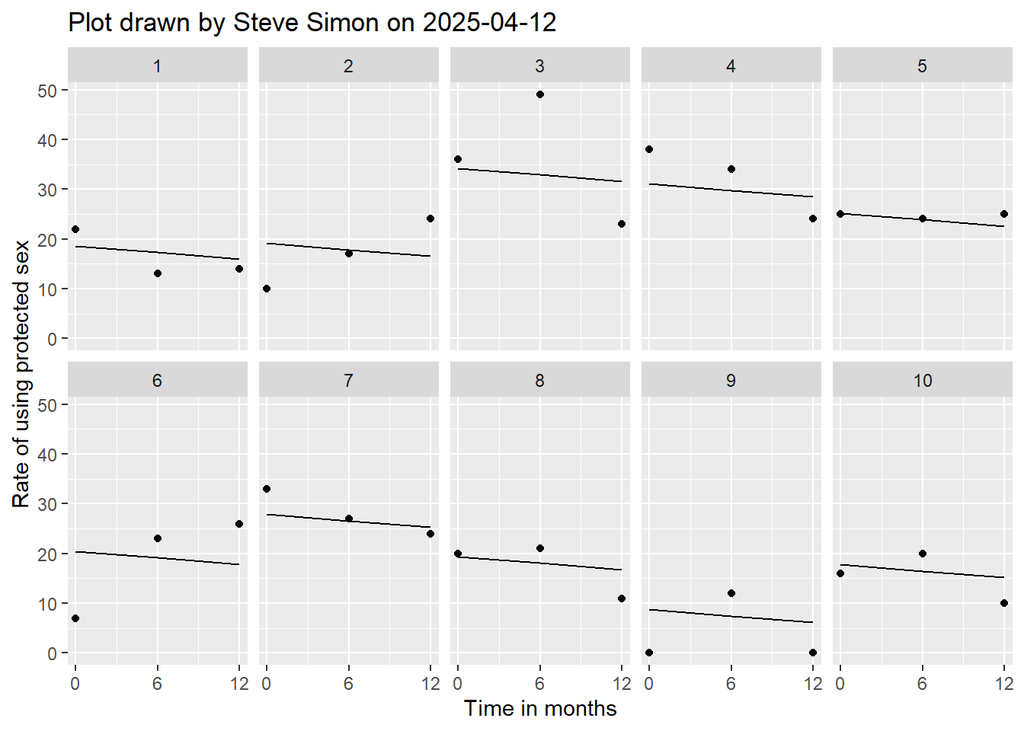

```r
hiv_3 |>
  ggplot() +
  aes(x=t, y=protected_sex) +
  geom_point() +
  geom_line(y=m3_predicted) +
  scale_x_continuous(breaks=c(0, 6, 12)) +
  ggtitle("Plot drawn by Steve Simon on 2025-04-12") +
  xlab("Time in months") +
  ylab("Rate of using protected sex") +
  facet_wrap(~ id, ncol=5) -> plot_3

plot_3
```

#### Interpretation of the output

The predicted values show a nearly flat line with only a small decrease over time. Notice how allowing each subject to have a different intercept leads to reasonable fits for at least some of the subjects.

## Check linearity

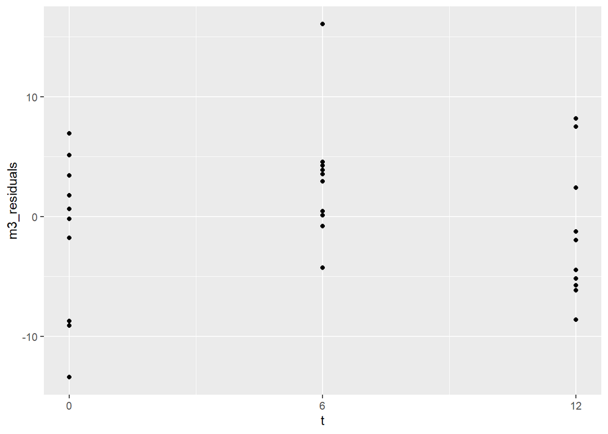

```r
hiv_3 |>
  select(t) |>
  bind_cols(tibble(m3_residuals)) |>
  ggplot() +
  aes(x=t, y=m3_residuals) +
  scale_x_continuous(breaks=c(0, 6, 12)) +
  geom_point() -> plot_4

plot_4
```

#### Comments on the code

In order to plot the residuals versus t, you must put both of them in the same data frame or tibble. There are several ways to do this. The [bind_cols](https://dplyr.tidyverse.org/reference/bind_cols.html) function will merge two data frames or tibbles side by side. They must have the same number of rows and the same order. The bind_cols function gets a bit confused when you are binding a vector, which is why you should convert the vector using the [tibble](https://tibble.tidyverse.org/reference/tibble.html) function.

#### Interpretation of the output

There is no obvious deviation from linearity in this graph. It looks like the 6 month value shows a bit less variability than the other time points, but this does not seem to be too serious.

## Check normality of residuals

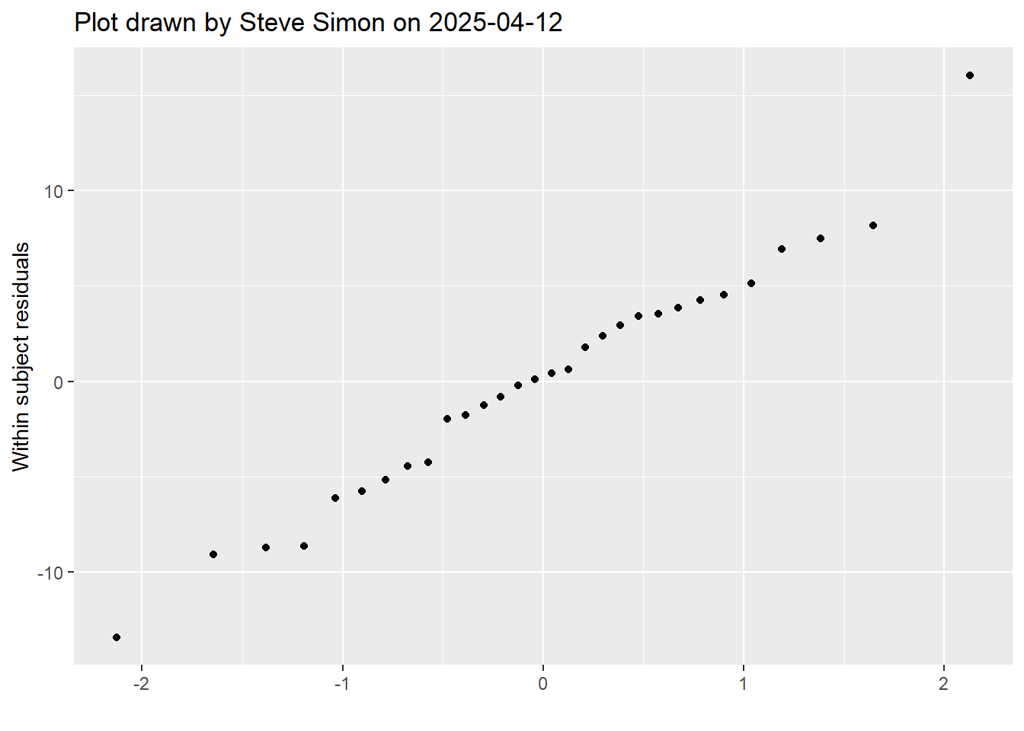

```r
tibble(m3_residuals) |>
  ggplot() +
  aes(sample=m3_residuals) +
  ggtitle("Plot drawn by Steve Simon on 2025-04-12") +
  xlab(" ") +
  ylab("Within subject residuals") +
  geom_qq() -> plot_5

plot_5
```

#### Comments on the code

The ggplot function expects to see a data frame or a tibble and m3_residuals is a vector. The [tibble](https://tibble.tidyverse.org/reference/tibble.html) function converts the vector into a tibble.

## Check normality of random intercepts

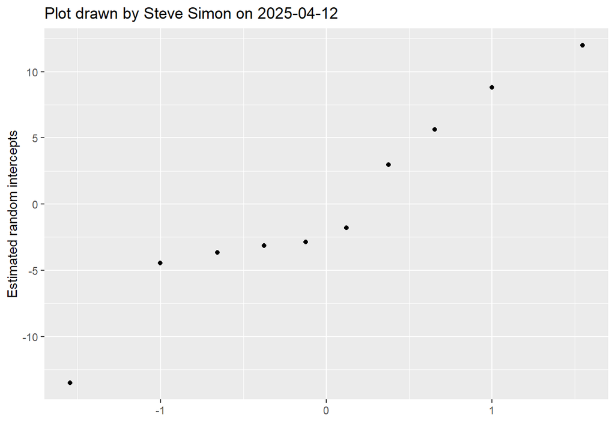

```r
tibble(x=unlist(m3_random_effects)) |>
  ggplot() +
  aes(sample=x) +
  ggtitle("Plot drawn by Steve Simon on 2025-04-12") +
  xlab(" ") +
  ylab("Estimated random intercepts") +
  geom_qq() -> plot_6

plot_6
```

#### Interpretation of the output

There is another outlier, but not too extreme among the random intercepts. Beyond that, the values appear to be fairly close to a normal distribution.

## Save everything

```r
save.image(file="../data/module12.RData")
```